# Lecture 12 - Autism

# Background

## What is autism?

- Lorna Wing’s triad of impairments:
  - difficulties in social interaction
  - difficulties in communication
  - lack of imagination / repetitive interests
- Heterogeneous – no two people are the same.
- There is a spectrum of different diagnoses.

## Diagnosis

- DSM criteria (Diagnostic and Statistical Manual of Mental Disorders, APA)
- Clinical observation
- Checklists
  - CHAT (checklist for autism in toddlers)
  - CARS (childhood autism rating scale)
  - DISCO (Diagnostic Interview for Social and Communication Disorders)
- ADOS (Autism Diagnostic Observation Schedule)
- ADI (Autism Diagnostic Interview)

(Hirota & King, 2023)

## How many children have autism?

- 3–4% of children and adolescents in the US
- 1% of the global population
- 0.7–1.5% in Switzerland
- Male-to-female ratio of approximately 3–4:1.

(Grosvenor et al., 2024)

# What factors cause autism?

## Possible factors

- environmental
  - vaccines
  - other environment?
- genetic
- cognitive
- neurobiological

## Vaccines

- **HELL NO!**
- There is a vast amount of high quality evidence that shows **NO LINK** between vaccines and autism.
- For those who want to read more see [here](https://publichealth.jhu.edu/2025/vaccines-do-not-cause-autism).

(DeStefano & Shimabukuro, 2019; Gabis et al., 2022)

## Other environmental factors

- Can a lack of a normal social environment cause autism?
  - “Refrigerator mother” - Bruno Bettelheim (1950’s) blamed “lack of maternal warmth” for autism in a child.
  - Theory is now totally discredited.
- What about sensory deprivation?
  - Blind and deaf children show autistic-like symptoms (Brown et al., 1997; Wolfe et al., 2002).
  - Neither blind nor deaf show all the symptoms of autism.
- Or extreme social deprivation?
  - Romanian orphanage studies (Rutter et al., 2007).
  - 10% had some autism symptoms at age 6, none had full symptoms, and many improved by age 12

## Genetic

- Bailey et al, 1995
  - 60% of MZ twin pairs were concordant for autism
  - no DZ twin pairs were concordant
  - shows high heritability (but not 100%)
- Ronald et al, 2005
  - studied over 3000 twin pairs in TEDS
  - find social behaviour is 62-76% heritable

Many genes have been implicated, none conclusively.

(Bailey et al., 1995; Ronald et al., 2005)

## Cognitive

Two different cognitive accounts:

- Theory of mind
- Weak central coherence

## Theory of mind

- The idea that people with autism have difficulty understanding other people’s mental states (beliefs, desires etc.).
- Proponents include Frith, Leslie, Happe, Baron-Cohen

## False beliefs

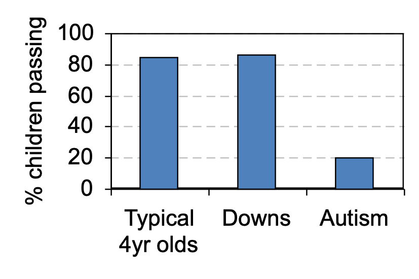

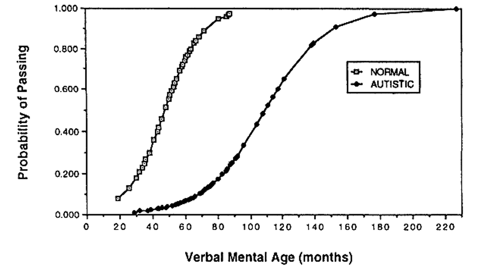

(Baron-Cohen et al., 1985; Happe, 1995)

## Animated shapes

[video not shown]

(Heider & Simmel, 1944)

## Animated shapes, autism and fMRI

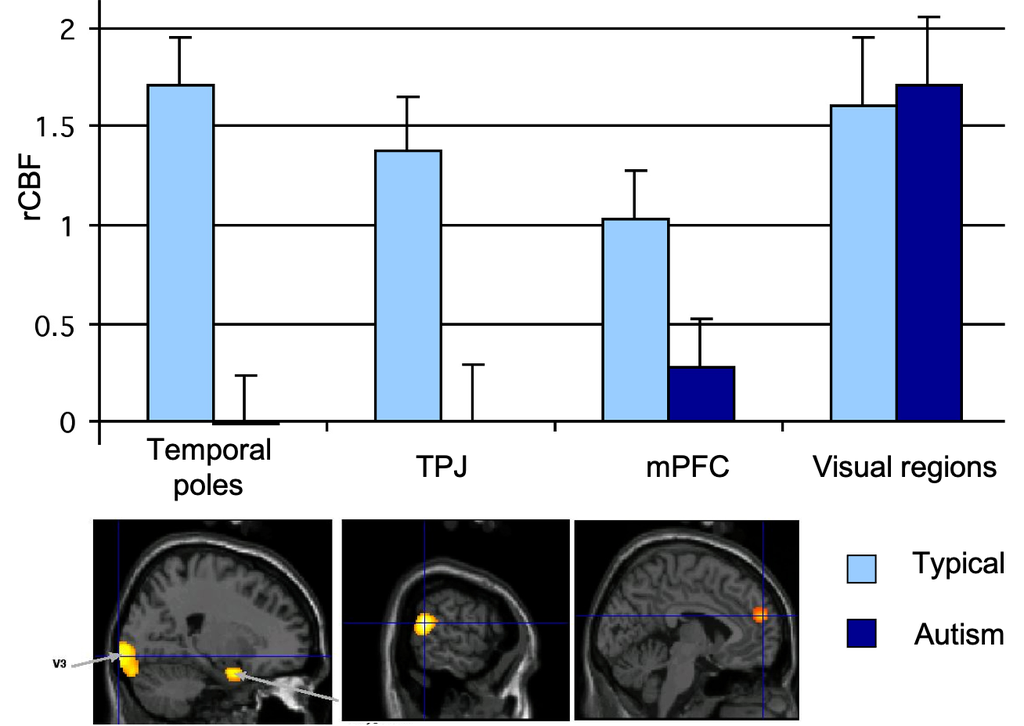

(Castelli et al., 2002)

## Weak central coherence

- The idea that people with autism have superior processing of detail and less superior processing of whole contexts.
- It can account for many non-social features and strengths.
- Do social tasks require more ‘central coherence’ than non-social tasks?

## The emebedded figures task

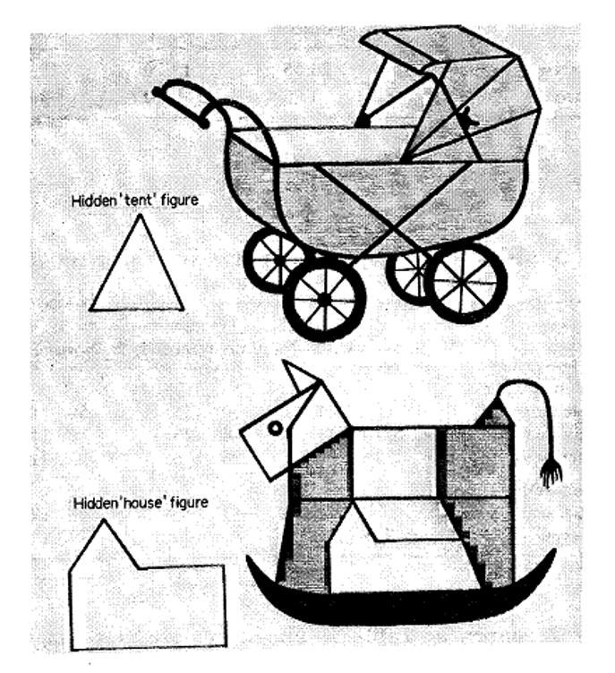

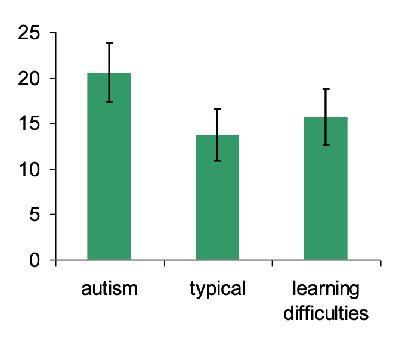

(Shah & Frith, 1983)

## The block design task

- Part of WISC IQ test
- Children with autism often perform very well on this task

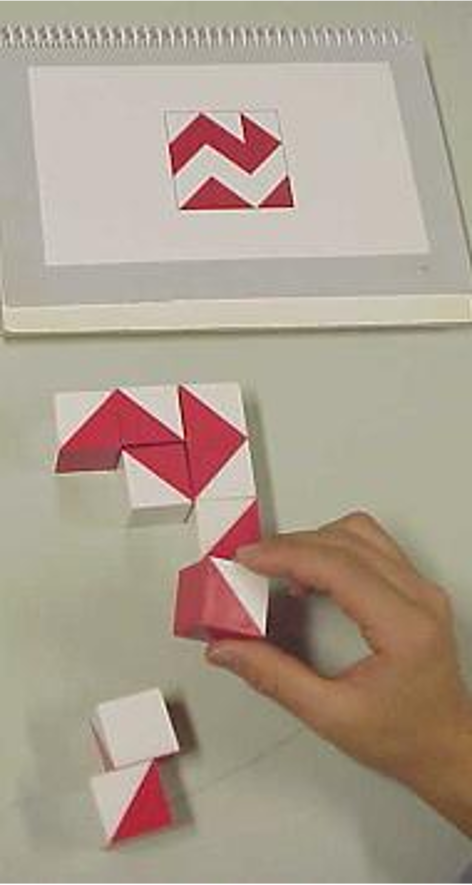

(Shah & Frith, 1993)

## Cognitive summary

- ToM
  - Lack of ToM in autism could cause breakdown in social interaction and communication
  - But it can’t explain savant skills or repetitive behaviours
- Weak central coherence
  - Weak central coherence could maybe account for many non-social features and strengths.
  - But do social tasks require more ‘central coherence’ than non-social tasks?

## Neurobiological

Two different neurobiological accounts:

- Broken mirror theory
- Underconnectivity

## Broken mirrors

- The idea that the ‘mirror neuron system’ is dysfunctional in autism
- Proponents include: Dapretto & Iacoboni, Oberman & Ramachandran, Justin Williams
- Evidence from: imitation behaviour, fMRI, EEG

[figure not shown]

## fMRI evidence

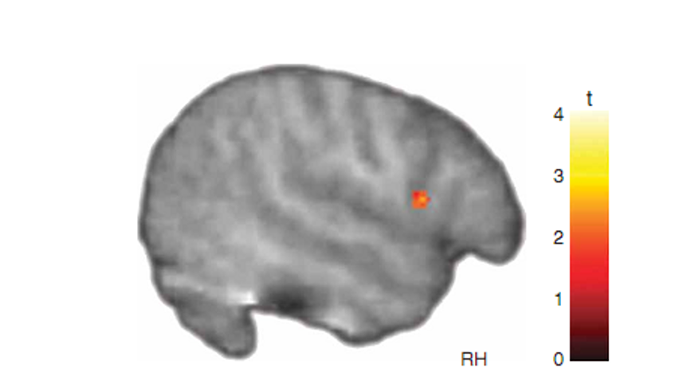

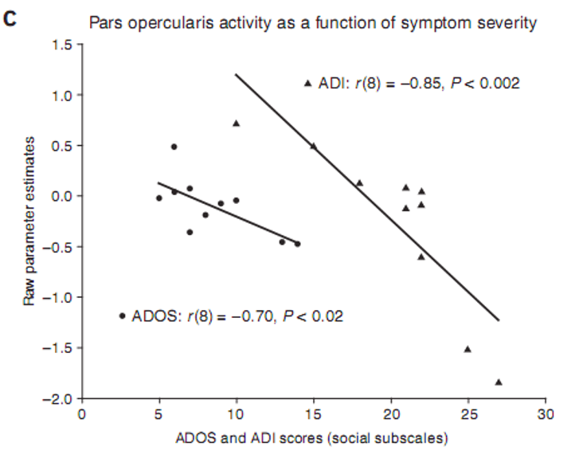

(Dapretto et al., 2006)

## Broken mirror criticisms

- Evidence for the theory is weak (Southgate & Hamilton A. F., 2008).
  - emotion and language tasks used, which are not the like the tasks that activate the mirror neurons in monkeys
  - types of imitation remain intact
- Empirical evidence that EEG and mu rhythmns can serve as an index of mirror neuron system has been heavily questioned (Hobson & Bishop, 2016, 2017).

## Underconnectivity

- The idea that the cortex is not connected together correctly in autism
  - Underconnectivity could cause lots of information processing problems
- Proponents include Minshew, Just, Courschesne
- Evidence comes from fMRI studies

## fMRI evidence

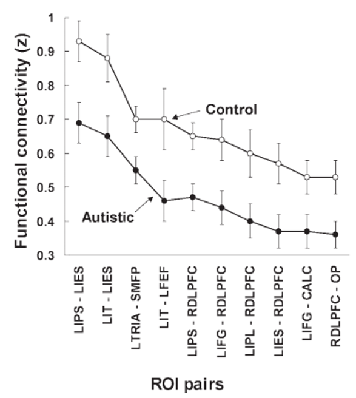

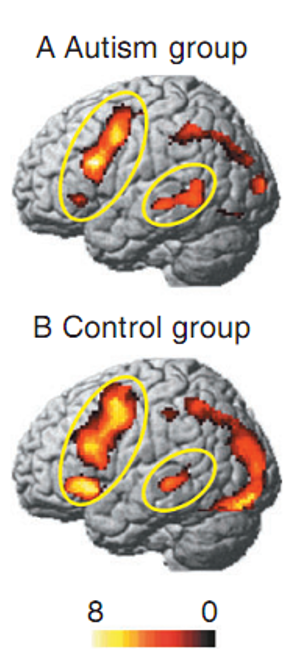

(Just et al., 2004, 2013)

## Neurobiological summary

- Broken mirror theory claims to explain many social features of autism, but it does not explain non-social features.
- And …
  - We still don’t know if the MNS contributes to Theory of Mind or language.
  - Mostly indirect measures of MNS function.
  - Tasks are emotional or meaningless actions – not like the tasks that activate the monkey MNS.
- Underconnectivity may explain weak central coherence
- But …
  - it may not explain social / communication problems (unless social information processing requires more ‘connections’)

## Many autisms?

- No single factor gives a complete explanation
- It is hard to explain both social and non-social symptoms

*Time to give up on a single explanation for autism* (Happé et al., 2006)

- Should study each part of the triad separately
- No model can yet account for all symptoms
- Different genetic and cognitive causes for each

# Take a break

# Part 2 - Read and discuss

## Discussion material

- break into small groups (~ 5 per group)
- discuss aspects of the lecture
- discuss aspects of the journal article: https://www.nature.com/articles/nn1770

And some articles in the popular press:

[Vaccines do not cause autism](https://publichealth.jhu.edu/2025/vaccines-do-not-cause-autism)

[So, what is going on in the United States?](https://www.npr.org/sections/shots-health-news/2025/11/20/nx-s1-5615040/cdc-rfk-childhood-vaccines-autism)

## References

Bailey, A., Couteur, A. L., Gottesman, I., Bolton, P., Simonoff, E., Yuzda, E., & Rutter, M. (1995). Autism as a strongly genetic disorder: Evidence from a British twin study. *Psychological Medicine*, *25*(1), 63–77. https://doi.org/10.1017/S0033291700028099

Baron-Cohen, S., Leslie, A. M., & Frith, U. (1985). Does the autistic child have a "theory of mind"? *Cognition*, *21*(1), 37–46. http://www.ncbi.nlm.nih.gov/htbin-post/Entrez/query?db=m&form=6&dopt=r&uid=2934210

Castelli, F., Frith, C., Happe, F., & Frith, U. (2002). Autism, Asperger syndrome and brain mechanisms for the attribution of mental states to animated shapes. *Brain*, *125*, 1839–49. http://www.ncbi.nlm.nih.gov/htbin-post/Entrez/query?db=m&form=6&dopt=r&uid=12135974 http://brain.oupjournals.org/cgi/content/full/125/8/1839 http://brain.oupjournals.org/cgi/content/abstract/125/8/1839

Dapretto, M., Davies, M. S., Pfeifer, J. H., Scott, A. A., Sigman, M., Bookheimer, S. Y., & Iacoboni, M. (2006). Understanding emotions in others: Mirror neuron dysfunction in children with autism spectrum disorders. *Nat Neurosci*, *9*(1), 28–30. http://www.ncbi.nlm.nih.gov/entrez/query.fcgi?cmd=Retrieve&db=PubMed&dopt=Citation&list_uids=16327784

DeStefano, F., & Shimabukuro, T. T. (2019). The MMR Vaccine and Autism. *Annual Review of Virology*, *6*, 585–600. https://doi.org/10.1146/annurev-virology-092818-015515

Gabis, L. V., Attia, O. L., Goldman, M., Barak, N., Tefera, P., Shefer, S., Shaham, M., & Lerman-Sagie, T. (2022). The myth of vaccination and autism spectrum. *European Journal of Paediatric Neurology*, *36*, 151–158. https://doi.org/10.1016/j.ejpn.2021.12.011

Grosvenor, L. P., Croen, L. A., Lynch, F. L., Marafino, B. J., Maye, M., Penfold, R. B., Simon, G. E., & Ames, J. L. (2024). Autism Diagnosis Among US Children and Adults, 2011-2022. *JAMA Network Open*, *7*(10), e2442218. https://doi.org/10.1001/jamanetworkopen.2024.42218

Happe, F. G. (1995). The role of age and verbal ability in the theory of mind task performance of subjects with autism. *Child Dev*, *66*(3), 843–855. http://www.ncbi.nlm.nih.gov/entrez/query.fcgi?cmd=Retrieve&db=PubMed&dopt=Citation&list_uids=7789204

Happé, F., Ronald, A., & Plomin, R. (2006). Time to give up on a single explanation for autism. *Nat Neurosci*, *9*(10), 1218–1220. https://doi.org/10.1038/nn1770

Heider, F., & Simmel, M. (1944). An Experimental Study of Apparent Behavior. *The American Journal of Psychology*.

Hirota, T., & King, B. H. (2023). Autism Spectrum Disorder: A Review. *JAMA*, *329*(2), 157–168. https://doi.org/10.1001/jama.2022.23661

Hobson, H. M., & Bishop, D. V. M. (2016). Mu suppression – A good measure of the human mirror neuron system? *Cortex*, *82*, 290–310. https://doi.org/10.1016/j.cortex.2016.03.019

Hobson, H. M., & Bishop, D. V. M. (2017). The interpretation of mu suppression as an index of mirror neuron activity: Past, present and future. *Royal Society Open Science*, *4*(3), 160662. https://doi.org/10.1098/rsos.160662

Just, M. A., Cherkassky, V. L., Keller, T. A., & Minshew, N. J. (2004). Cortical activation and synchronization during sentence comprehension in high-functioning autism: Evidence of underconnectivity. *Brain*, *127*(8), 1811–1821. https://doi.org/10.1093/brain/awh199

Just, M. A., Keller, T. A., & Kana, R. K. (2013). A Theory of Autism Based on Frontal-Posterior Underconnectivity. In *Development and Brain Systems in Autism*. Psychology Press.

Ronald, A., Happé, F., & Plomin, R. (2005). The genetic relationship between individual differences in social and nonsocial behaviours characteristic of autism. *Developmental Science*, *8*(5), 444–458. https://doi.org/10.1111/j.1467-7687.2005.00433.x

Shah, A., & Frith, U. (1983). An Islet of Ability in Autistic Children: A Research Note. *Journal of Child Psychology and Psychiatry*, *24*(4), 613–620. https://doi.org/10.1111/j.1469-7610.1983.tb00137.x

Shah, A., & Frith, U. (1993). Why do autistic individuals show superior performance on the block design task? *J Child Psychol Psychiatry*, *34*(8), 1351–64. http://www.ncbi.nlm.nih.gov/htbin-post/Entrez/query?db=m&form=6&dopt=r&uid=8294523

Southgate, V., & Hamilton A. F. (2008). Unbroken mirrors: Challenging a theory of Autism. *Trends Cogn Sci*, *12*(6), 225–229. http://www.ncbi.nlm.nih.gov/entrez/query.fcgi?cmd=Retrieve&db=PubMed&dopt=Citation&list_uids=18479959

## Acknowledgements

- Unless otherwise specified, icons and images were used under license from [The Noun Project](https://thenounproject.com/)
- Slides were created with [Quarto](https://quarto.org/) and [RevealJS](https://revealjs.com/)